# Archived Soil Incubations Manuscript Figures

## Storage duration effect on <sup>14</sup>C-CO<sub>2</sub> (Experiment 3)

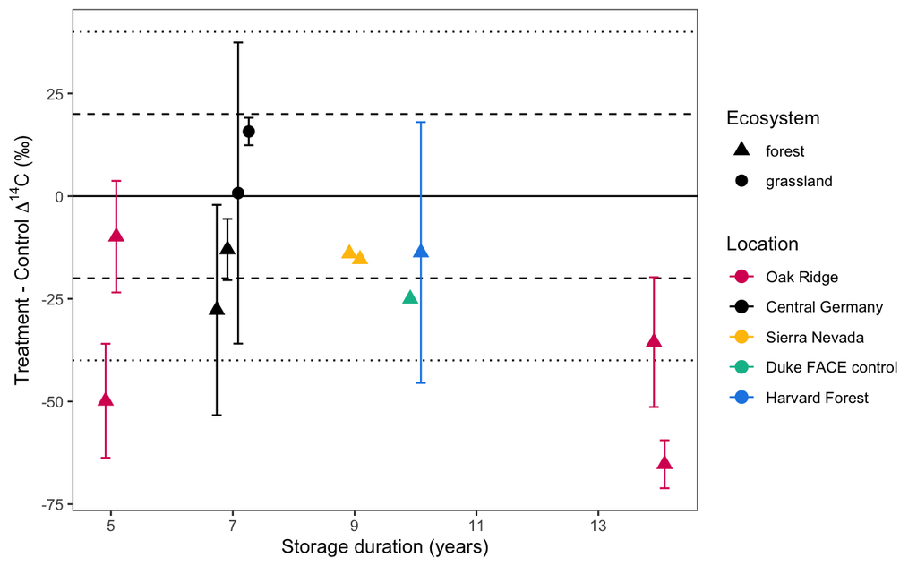

> **Fig. 5. Change in <sup>14</sup>C-CO<sub>2</sub> in relation to storage duration**

# Discussion

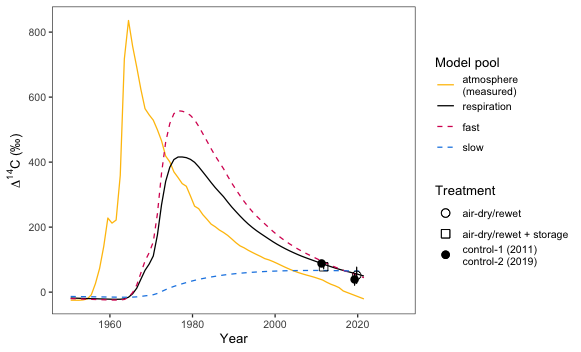

> **Fig 6a. Modeled trajectories of $\Delta$<sup>14</sup>C over time for a hypothetical 2-pool soil carbon model in relationship to observed atmospheric $\Delta$<sup>14</sup>C**

> *Caption:* Modeled curves derived from a hypothetical two-pool parallel model system in which inputs are partitioned between a fast cycling soil carbon pool (*k* = 1/6) and a more slowly cycling pool (*k* = 1/100) without any tranfers between the pools. Carbon stocks and pool sizes are based on density fraction data for the Hainich Forest (Schrumpf et al. 2013); decomposition rates are chosen to be realistic but are arbitrary. Atmospheric $\Delta$<sup>14</sup>C data up to the year 2015 are from Graven et al. (2017), while data points beyond 2015 use the extrapolation method from Sierra (2018). All atmospheric radiocarbon data is for the northern hemisphere (zone 2).

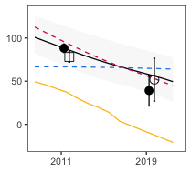

> **Fig 6b. Potential shifts in $\Delta$<sup>14</sup>C of respired CO<sub>2</sub> in response to treatment**